# ChinmayRozekar_MachineLearning_Project2

## Model Building

### Model Evaluation Criterion

The model can make wrong predictions in two ways:

- Predicting a customer will not accept a loan, but in reality, the customer does accept it (False Negative)
- Predicting a customer will accept a loan, but in reality, they do not (False Positive)

**Which case is more important?**

- If we predict that a customer will not accept the loan but they actually do, the bank misses an opportunity to sell a loan — resulting in loss of potential revenue.
- If we predict that a customer will accept the loan but they don’t, the bank may waste resources on follow-ups or promotions — a comparatively smaller loss.

**How to reduce the losses?**

The bank would prefer to maximize recall — higher recall means fewer False Negatives, increasing the chances of capturing all interested customers and maximizing loan sales.

```python
# defining a function to compute different metrics to check performance of a classification model built using sklearn
def model_performance_classification_sklearn(model, predictors, target):
    """
    Function to compute different metrics to check classification model performance

    model: classifier
    predictors: independent variables
    target: dependent variable
    """

    # predicting using the independent variables
    pred = model.predict(predictors)

    acc = accuracy_score(target, pred)  # to compute Accuracy
    recall = recall_score(target, pred)  # to compute Recall
    precision = precision_score(target, pred)  # to compute Precision
    f1 = f1_score(target, pred)  # to compute F1-score

    # creating a dataframe of metrics
    df_perf = pd.DataFrame(
        {"Accuracy": acc, "Recall": recall, "Precision": precision, "F1": f1,},
        index=[0],
    )

    return df_perf
```

```python
def confusion_matrix_sklearn(model, predictors, target):
    """
    To plot the confusion_matrix with percentages

    model: classifier
    predictors: independent variables
    target: dependent variable
    """
    y_pred = model.predict(predictors)
    cm = confusion_matrix(target, y_pred)
    labels = np.asarray(
        [
            ["{0:0.0f}".format(item) + "\n{0:.2%}".format(item / cm.flatten().sum())]
            for item in cm.flatten()
        ]
    ).reshape(2, 2)

    plt.figure(figsize=(6, 4))
    sns.heatmap(cm, annot=labels, fmt="")
    plt.ylabel("True label")
    plt.xlabel("Predicted label")
```

### Model Building

**Decision Tree (default)**

```python
model0 = DecisionTreeClassifier(random_state=1)
model0.fit(X_train, y_train)
```

```
DecisionTreeClassifier(random_state=1)
```

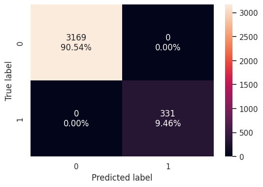

```python
confusion_matrix_sklearn(model0, X_train, y_train)
```

```python
decision_tree_default_perf_train = model_performance_classification_sklearn(
    model0, X_train, y_train
)
decision_tree_default_perf_train
```

|  | Accuracy | Recall | Precision | F1 |
| --- | --- | --- | --- | --- |
| 0 | 1.0 | 1.0 | 1.0 | 1.0 |

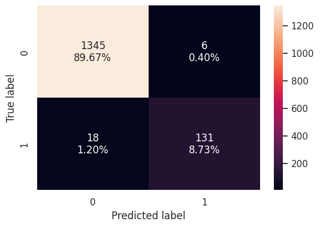

```python
confusion_matrix_sklearn(model0, X_test, y_test)
```

```python
decision_tree_default_perf_test = model_performance_classification_sklearn(
    model0, X_test, y_test
)
decision_tree_default_perf_test
```

|  | Accuracy | Recall | Precision | F1 |
| --- | --- | --- | --- | --- |
| 0 | 0.984 | 0.879195 | 0.956204 | 0.916084 |

**Decision Tree (with class_weights)**

- If the frequency of class A is 10% and the frequency of class B is 90%, then class B will become the dominant class and the decision tree will become biased toward the dominant classes
- In this case, we will set class_weight = "balanced", which will automatically adjust the weights to be inversely proportional to the class frequencies in the input data
- class_weight is a hyperparameter for the decision tree classifier

```python
model1 = DecisionTreeClassifier(random_state=1, class_weight="balanced")
model1.fit(X_train, y_train)
```

```
DecisionTreeClassifier(class_weight='balanced', random_state=1)
```

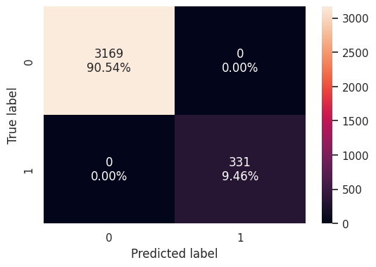

```python
confusion_matrix_sklearn(model1, X_train, y_train)
```

```python
decision_tree_perf_train = model_performance_classification_sklearn(
    model1, X_train, y_train
)
decision_tree_perf_train
```

|  | Accuracy | Recall | Precision | F1 |
| --- | --- | --- | --- | --- |
| 0 | 1.0 | 1.0 | 1.0 | 1.0 |

- The model perfectly classifies all training data with 0 errors, which indicates that the decision tree has learned all patterns in the training set.
- This typically results in overfitting, where the model performs well on training data but may not generalize effectively to unseen test data.

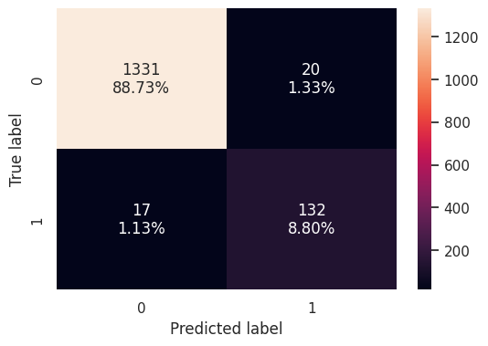

```python
confusion_matrix_sklearn(model1, X_test, y_test)
```

```python
decision_tree_perf_test = model_performance_classification_sklearn(
    model1, X_test, y_test
)
decision_tree_perf_test
```

|  | Accuracy | Recall | Precision | F1 |
| --- | --- | --- | --- | --- |
| 0 | 0.975333 | 0.885906 | 0.868421 | 0.877076 |

- The model achieves **perfect scores on the training set**, indicating it has likely **overfit** by memorizing the data.
- On the test set, there's a **noticeable drop in performance**, confirming that the model's ability to **generalize to new data is limited**.

## Model Performance Improvement

**Decision Tree (Pre-pruning)**

- Hyperparameter tuning is crucial because it directly affects the performance of a model.
- Unlike model parameters which are learned during training, hyperparameters need to be set before training.
- Effective hyperparameter tuning helps in improving the performance and robustness of the model.
- The below custom loop for hyperparameter tuning iterates over predefined parameter values to identify the best model based on the metric of choice (recall score).

```python
# Define the parameters of the tree to iterate over
max_depth_values = np.arange(2, 7, 2)
max_leaf_nodes_values = [50, 75, 150, 250]
min_samples_split_values = [10, 30, 50, 70]

# Initialize variables to store the best model and its performance
best_estimator = None
best_score_diff = float('inf')
best_test_score = 0.0

# Iterate over all combinations of the specified parameter values
for max_depth in max_depth_values:
    for max_leaf_nodes in max_leaf_nodes_values:
        for min_samples_split in min_samples_split_values:

            # Initialize the tree with the current set of parameters
            estimator = DecisionTreeClassifier(
                max_depth=max_depth,
                max_leaf_nodes=max_leaf_nodes,
                min_samples_split=min_samples_split,
                class_weight='balanced',
                random_state=42
            )

            # Fit the model to the training data
            estimator.fit(X_train, y_train)

            # Make predictions on the training and test sets
            y_train_pred = estimator.predict(X_train)
            y_test_pred = estimator.predict(X_test)

            # Calculate recall scores for training and test sets
            train_recall_score = recall_score(y_train, y_train_pred)
            test_recall_score = recall_score(y_test, y_test_pred)

            # Calculate the absolute difference between training and test recall scores
            score_diff = abs(train_recall_score - test_recall_score)

            # Update the best estimator and best score if the current one has a smaller score difference
            if (score_diff < best_score_diff) & (test_recall_score > best_test_score):
                best_score_diff = score_diff
                best_test_score = test_recall_score
                best_estimator = estimator

# Print the best parameters
print("Best parameters found:")
print(f"Max depth: {best_estimator.max_depth}")
print(f"Max leaf nodes: {best_estimator.max_leaf_nodes}")
print(f"Min samples split: {best_estimator.min_samples_split}")
print(f"Best test recall score: {best_test_score}")
```

```
Best parameters found:
Max depth: 2
Max leaf nodes: 50
Min samples split: 10
Best test recall score: 1.0
```

```python
# creating an instance of the best model
model2 = best_estimator

# fitting the best model to the training data
model2.fit(X_train, y_train)
```

```
DecisionTreeClassifier(class_weight='balanced', max_depth=np.int64(2),
                       max_leaf_nodes=50, min_samples_split=10,
                       random_state=42)
```

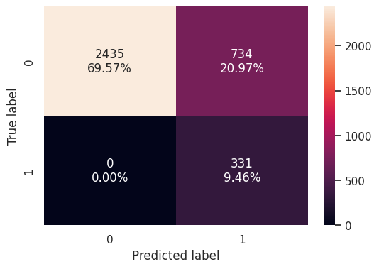

```python
confusion_matrix_sklearn(model2, X_train, y_train)
```

```python
decision_tree_tune_perf_train = model_performance_classification_sklearn(
    model2, X_train, y_train
)
decision_tree_tune_perf_train
```

|  | Accuracy | Recall | Precision | F1 |
| --- | --- | --- | --- | --- |
| 0 | 0.790286 | 1.0 | 0.310798 | 0.474212 |

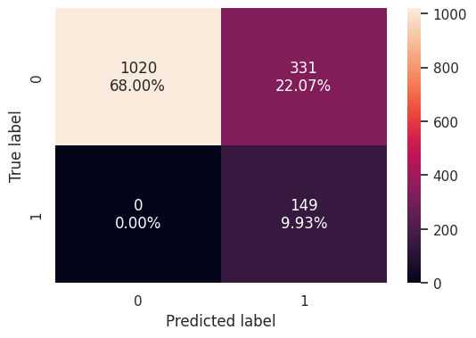

```python
confusion_matrix_sklearn(model2, X_test, y_test)
```

```python
decision_tree_tune_perf_test = model_performance_classification_sklearn(
    model2, X_test, y_test
)
decision_tree_tune_perf_test
```

|  | Accuracy | Recall | Precision | F1 |
| --- | --- | --- | --- | --- |
| 0 | 0.779333 | 1.0 | 0.310417 | 0.473768 |

- Accuracy is dropped in Pre prunning as compared to the original tree

```python
feature_names = list(X_train.columns)
importances = model2.feature_importances_
indices = np.argsort(importances)
```

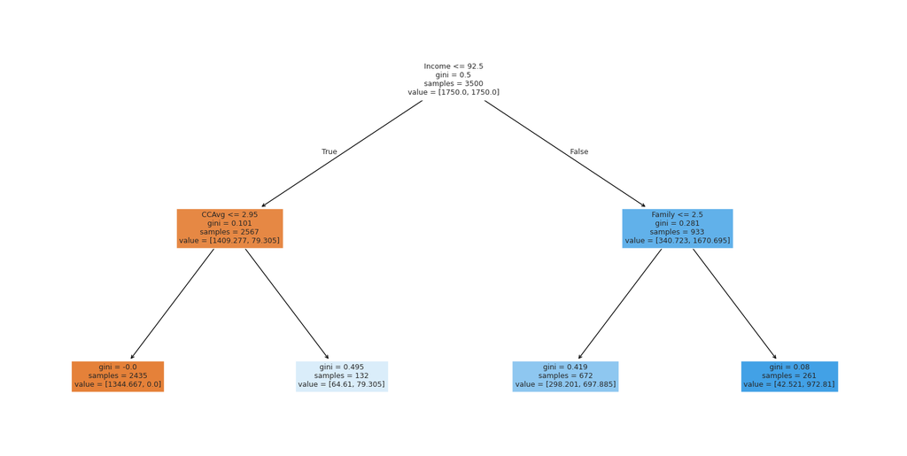

```python
plt.figure(figsize=(20, 10))
out = tree.plot_tree(
    model2,
    feature_names=feature_names,
    filled=True,
    fontsize=9,
    node_ids=False,
    class_names=None,
)
# below code will add arrows to the decision tree split if they are missing
for o in out:
    arrow = o.arrow_patch
    if arrow is not None:
        arrow.set_edgecolor("black")
        arrow.set_linewidth(1)
plt.show()
```

```python
# Text report showing the rules of a decision tree -
print(tree.export_text(model2, feature_names=feature_names, show_weights=True))
```

```
|--- Income <= 92.50
|   |--- CCAvg <= 2.95
|   |   |--- weights: [1344.67, 0.00] class: 0
|   |--- CCAvg >  2.95
|   |   |--- weights: [64.61, 79.31] class: 1
|--- Income >  92.50
|   |--- Family <= 2.50
|   |   |--- weights: [298.20, 697.89] class: 1
|   |--- Family >  2.50
|   |   |--- weights: [42.52, 972.81] class: 1
```

- If the Income is less than or equal to 92.5 and CCAvg is less than or equal to 2.95, then the customer is most likely not interested in a personal loan (class 0).
- If the Income is greater than 92.5 and Family size is greater than 2.5, then the customer is most likely interested in a personal loan (class 1).

```python
importances = model2.feature_importances_
importances
```

[output not shown]

[output cut: 41 more lines]

[output not shown]

```python
# Show feature names with importance > 0
feature_importances = pd.Series(importances, index=X.columns)
important_features = feature_importances[feature_importances > 0].sort_values(ascending=False)
print(important_features)
```

```
Income    0.876529
CCAvg     0.066940
Family    0.056531
dtype: float64
```

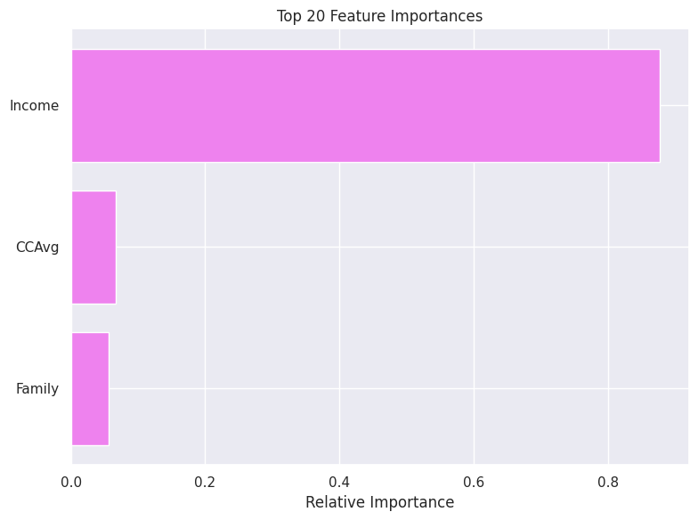

```python
# Get feature importances as a Series
importances = model2.feature_importances_
feature_importances = pd.Series(importances, index=X.columns)

# Filter and sort top features
top_features = feature_importances[feature_importances > 0].sort_values(ascending=True).tail(20)

# Plot
plt.figure(figsize=(8, 6))
plt.title("Top 20 Feature Importances")
plt.barh(top_features.index, top_features.values, color="violet")
plt.xlabel("Relative Importance")
plt.tight_layout()
plt.show()
```

- The decision tree model relies heavily on just a few key features, with Income being the most dominant, followed by CCAvg and Family — these are the only features with non-zero importance scores.
- All other features, including many one-hot encoded ZIP codes and education levels, were not used at all in the tree, as their importance values are 0. This means the model found them irrelevant for predicting loan acceptance in this case.

**Decision Tree (Post pruning)**

Cost complexity pruning is a technique in DecisionTreeClassifier that helps control the size of a decision tree using the parameter ccp_alpha.

As ccp_alpha increases, more branches (nodes) are pruned, resulting in a simpler and less overfit tree.

The pruning process starts by removing the weakest links—nodes with the smallest contribution (lowest effective alpha) to the model.

You can use cost_complexity_pruning_path to explore different ccp_alpha values and their impact on leaf impurity, helping you choose the optimal pruning level.

```python
clf = DecisionTreeClassifier(random_state=1, class_weight="balanced")
path = clf.cost_complexity_pruning_path(X_train, y_train)
ccp_alphas, impurities = abs(path.ccp_alphas), path.impurities
```

```python
pd.DataFrame(path)
```

|  | ccp_alphas | impurities |
| --- | --- | --- |
| 0 | 0.000000e+00 | -6.129189e-15 |
| 1 | 5.255079e-19 | -6.128663e-15 |
| 2 | 5.255079e-19 | -6.128138e-15 |
| 3 | 1.051016e-18 | -6.127087e-15 |
| 4 | 1.257806e-17 | -6.114509e-15 |
| 5 | 2.857143e-04 | 8.571429e-04 |
| 6 | 2.887484e-04 | 3.167130e-03 |
| 7 | 2.891322e-04 | 5.191056e-03 |
| 8 | 2.998950e-04 | 6.090741e-03 |
| 9 | 3.049400e-04 | 7.920381e-03 |
| 10 | 3.101577e-04 | 8.230539e-03 |
| 11 | 3.151594e-04 | 9.806336e-03 |
| 12 | 5.517639e-04 | 1.035810e-02 |
| 13 | 5.900285e-04 | 1.094813e-02 |
| 14 | 5.921354e-04 | 1.272453e-02 |
| 15 | 6.616439e-04 | 1.404782e-02 |
| 16 | 7.538167e-04 | 1.480164e-02 |
| 17 | 7.721068e-04 | 1.634585e-02 |
| 18 | 8.981804e-04 | 1.724403e-02 |
| 19 | 9.269294e-04 | 1.817096e-02 |
| 20 | 1.461815e-03 | 1.963278e-02 |
| 21 | 1.671123e-03 | 2.130390e-02 |
| 22 | 1.768018e-03 | 2.307192e-02 |
| 23 | 2.221376e-03 | 2.751467e-02 |
| 24 | 2.375809e-03 | 2.989048e-02 |
| 25 | 2.472660e-03 | 3.483580e-02 |
| 26 | 3.297255e-03 | 3.813305e-02 |
| 27 | 3.344493e-03 | 4.147755e-02 |
| 28 | 3.503794e-03 | 4.498134e-02 |
| 29 | 3.602932e-03 | 5.218720e-02 |
| 30 | 3.729690e-03 | 5.591689e-02 |
| 31 | 4.941457e-03 | 6.085835e-02 |
| 32 | 4.970987e-03 | 7.080032e-02 |
| 33 | 2.255792e-02 | 9.335825e-02 |
| 34 | 3.708749e-02 | 2.046207e-01 |
| 35 | 2.953793e-01 | 5.000000e-01 |

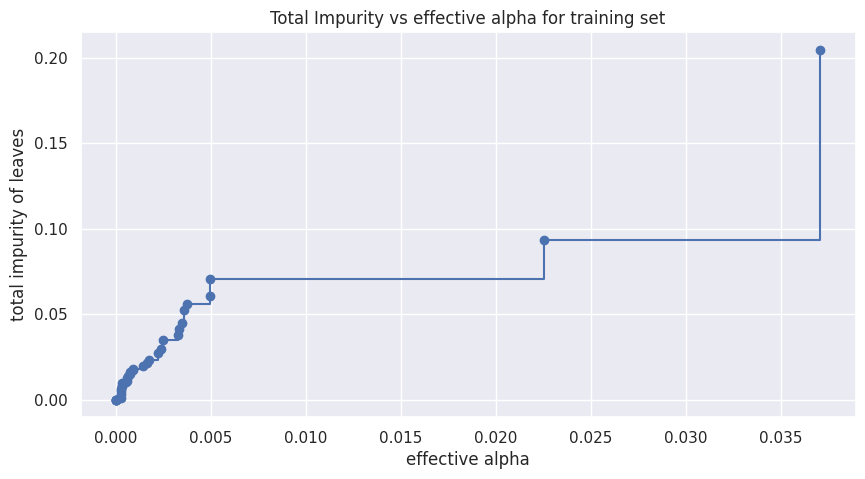

```python
fig, ax = plt.subplots(figsize=(10, 5))
ax.plot(ccp_alphas[:-1], impurities[:-1], marker="o", drawstyle="steps-post")
ax.set_xlabel("effective alpha")
ax.set_ylabel("total impurity of leaves")
ax.set_title("Total Impurity vs effective alpha for training set")
plt.show()
```

Next, we train a decision tree using the effective alphas. The last value in ccp_alphas is the alpha value that prunes the whole tree, leaving the tree, clfs[-1], with one node.

```python
clfs = []
for ccp_alpha in ccp_alphas:
    clf = DecisionTreeClassifier(
        random_state=1, ccp_alpha=ccp_alpha, class_weight="balanced"
    )
    clf.fit(X_train, y_train)
    clfs.append(clf)
print(
    "Number of nodes in the last tree is: {} with ccp_alpha: {}".format(
        clfs[-1].tree_.node_count, ccp_alphas[-1]
    )
)
```

```
Number of nodes in the last tree is: 1 with ccp_alpha: 0.2953792759992327
```

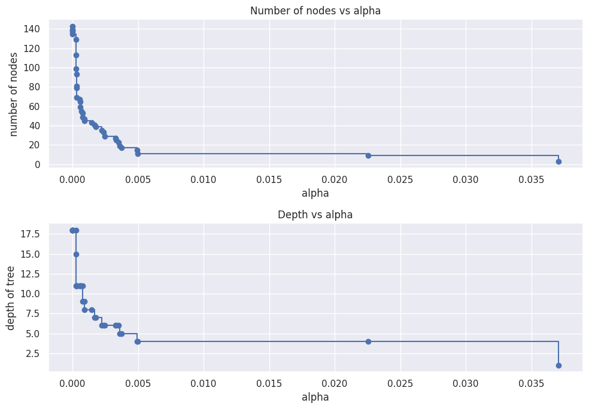

```python
clfs = clfs[:-1]
ccp_alphas = ccp_alphas[:-1]

node_counts = [clf.tree_.node_count for clf in clfs]
depth = [clf.tree_.max_depth for clf in clfs]
fig, ax = plt.subplots(2, 1, figsize=(10, 7))
ax[0].plot(ccp_alphas, node_counts, marker="o", drawstyle="steps-post")
ax[0].set_xlabel("alpha")
ax[0].set_ylabel("number of nodes")
ax[0].set_title("Number of nodes vs alpha")
ax[1].plot(ccp_alphas, depth, marker="o", drawstyle="steps-post")
ax[1].set_xlabel("alpha")
ax[1].set_ylabel("depth of tree")
ax[1].set_title("Depth vs alpha")
fig.tight_layout()
```

```python
recall_train = []
for clf in clfs:
    pred_train = clf.predict(X_train)
    values_train = recall_score(y_train, pred_train)
    recall_train.append(values_train)
```

```python
recall_test = []
for clf in clfs:
    pred_test = clf.predict(X_test)
    values_test = recall_score(y_test, pred_test)
    recall_test.append(values_test)
```

```python
train_scores = [clf.score(X_train, y_train) for clf in clfs]
test_scores = [clf.score(X_test, y_test) for clf in clfs]
```

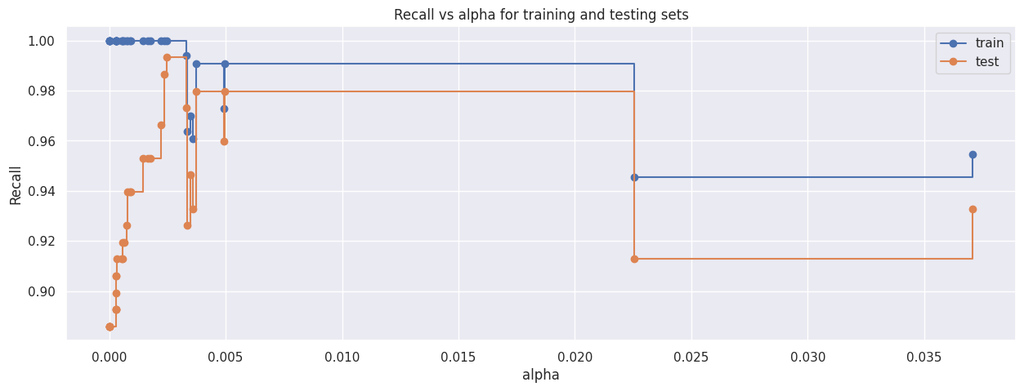

```python
fig, ax = plt.subplots(figsize=(15, 5))
ax.set_xlabel("alpha")
ax.set_ylabel("Recall")
ax.set_title("Recall vs alpha for training and testing sets")
ax.plot(
    ccp_alphas, recall_train, marker="o", label="train", drawstyle="steps-post",
)
ax.plot(ccp_alphas, recall_test, marker="o", label="test", drawstyle="steps-post")
ax.legend()
plt.show()
```

```python
# creating the model where we get highest train and test recall
index_best_model = np.argmax(recall_test)
best_model = clfs[index_best_model]
print(best_model)
```

```
DecisionTreeClassifier(ccp_alpha=np.float64(0.0024726598786421958),
                       class_weight='balanced', random_state=1)
```

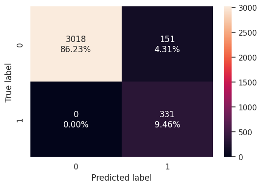

```python
model4 = best_model
confusion_matrix_sklearn(model4, X_train, y_train)
```

```python
decision_tree_post_perf_train = model_performance_classification_sklearn(
    model4, X_train, y_train
)
decision_tree_post_perf_train
```

|  | Accuracy | Recall | Precision | F1 |
| --- | --- | --- | --- | --- |
| 0 | 0.956857 | 1.0 | 0.686722 | 0.814268 |

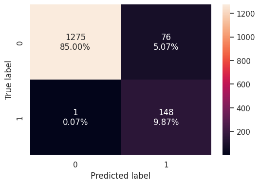

```python
confusion_matrix_sklearn(model4, X_test, y_test)
```

```python
decision_tree_post_test = model_performance_classification_sklearn(
    model4, X_test, y_test
)
decision_tree_post_test
```

|  | Accuracy | Recall | Precision | F1 |
| --- | --- | --- | --- | --- |
| 0 | 0.948667 | 0.993289 | 0.660714 | 0.793566 |

- The model maintains **high accuracy and recall** on both training (95.7% accuracy, 100% recall) and test sets (94.9% accuracy, 99.3% recall), indicating it is effectively identifying most of the positive (loan-accepting) cases.
- However, the **precision is relatively low** on both sets (around 66–69%), suggesting the model also predicts many false positives — i.e., it often predicts a customer will take a loan when they won’t.
- The balanced **F1-score (~0.79–0.81)** indicates a reasonable trade-off between precision and recall, and the **small performance gap** between train and test suggests **good generalization** after pruning.

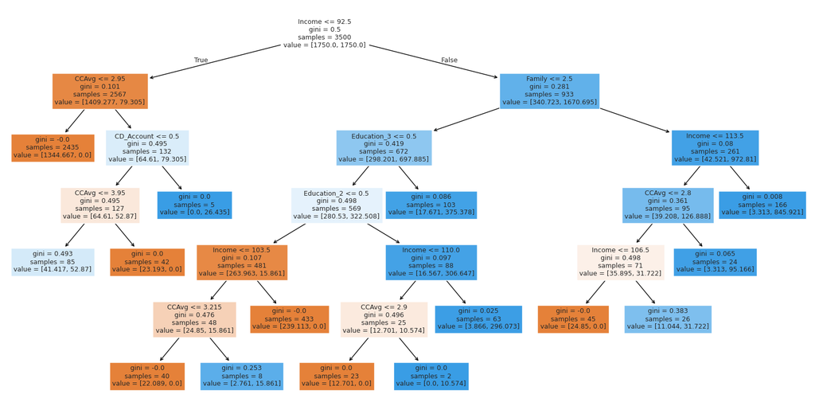

```python
plt.figure(figsize=(20, 10))

out = tree.plot_tree(
    model4,
    feature_names=feature_names,
    filled=True,
    fontsize=9,
    node_ids=False,
    class_names=None,
)
for o in out:
    arrow = o.arrow_patch
    if arrow is not None:
        arrow.set_edgecolor("black")
        arrow.set_linewidth(1)
plt.show()
```

```python
# Text report showing the rules of a decision tree -

print(tree.export_text(model4, feature_names=feature_names, show_weights=True))
```

```
|--- Income <= 92.50
|   |--- CCAvg <= 2.95
|   |   |--- weights: [1344.67, 0.00] class: 0
|   |--- CCAvg >  2.95
|   |   |--- CD_Account <= 0.50
|   |   |   |--- CCAvg <= 3.95
|   |   |   |   |--- weights: [41.42, 52.87] class: 1
|   |   |   |--- CCAvg >  3.95
|   |   |   |   |--- weights: [23.19, 0.00] class: 0
|   |   |--- CD_Account >  0.50
|   |   |   |--- weights: [0.00, 26.44] class: 1
|--- Income >  92.50
|   |--- Family <= 2.50
|   |   |--- Education_3 <= 0.50
|   |   |   |--- Education_2 <= 0.50
|   |   |   |   |--- Income <= 103.50
|   |   |   |   |   |--- CCAvg <= 3.21
|   |   |   |   |   |   |--- weights: [22.09, 0.00] class: 0
|   |   |   |   |   |--- CCAvg >  3.21
|   |   |   |   |   |   |--- weights: [2.76, 15.86] class: 1
|   |   |   |   |--- Income >  103.50
|   |   |   |   |   |--- weights: [239.11, 0.00] class: 0
|   |   |   |--- Education_2 >  0.50
|   |   |   |   |--- Income <= 110.00
|   |   |   |   |   |--- CCAvg <= 2.90
|   |   |   |   |   |   |--- weights: [12.70, 0.00] class: 0
|   |   |   |   |   |--- CCAvg >  2.90
|   |   |   |   |   |   |--- weights: [0.00, 10.57] class: 1
|   |   |   |   |--- Income >  110.00
|   |   |   |   |   |--- weights: [3.87, 296.07] class: 1
|   |   |--- Education_3 >  0.50
|   |   |   |--- weights: [17.67, 375.38] class: 1
|   |--- Family >  2.50
|   |   |--- Income <= 113.50
|   |   |   |--- CCAvg <= 2.80
|   |   |   |   |--- Income <= 106.50
|   |   |   |   |   |--- weights: [24.85, 0.00] class: 0
|   |   |   |   |--- Income >  106.50
|   |   |   |   |   |--- weights: [11.04, 31.72] class: 1
|   |   |   |--- CCAvg >  2.80
|   |   |   |   |--- weights: [3.31, 95.17] class: 1
|   |   |--- Income >  113.50
|   |   |   |--- weights: [3.31, 845.92] class: 1
```

```python
importances = model4.feature_importances_
indices = np.argsort(importances)
```

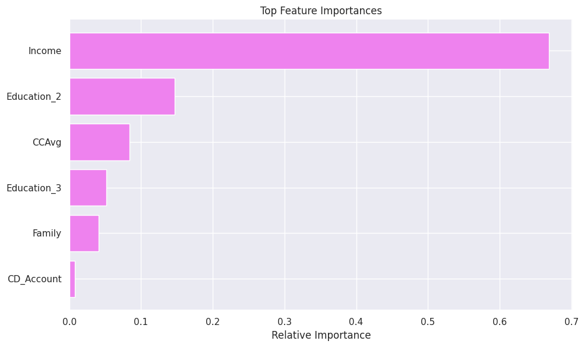

```python
# Get feature importances and match with feature names
importances = model4.feature_importances_
feature_importances = pd.Series(importances, index=X.columns)

# Keep only non-zero and top N important features
top_features = feature_importances[feature_importances > 0].sort_values(ascending=True).tail(15)

# Plot
plt.figure(figsize=(10, 6))
plt.title("Top Feature Importances")
plt.barh(top_features.index, top_features.values, color="violet")
plt.xlabel("Relative Importance")
plt.tight_layout()
plt.show()
```

- **Income** is by far the most influential feature in predicting personal loan acceptance, contributing to nearly **70% of the decision-making** in the model.
- Other features like **Education_2**, **CCAvg**, and **Education_3** also play a role, but their importance is much smaller in comparison to Income.
- Features like **Family** and **CD_Account** have minimal impact, suggesting that they contribute very little to the final decision in this pruned tree model.

## Model Performance Comparison and Final Model Selection

```python
# training performance comparison

models_train_comp_df = pd.concat(
    [
        decision_tree_default_perf_train.T,
        decision_tree_perf_train.T,
        decision_tree_tune_perf_train.T,
        decision_tree_post_perf_train.T,
    ],
    axis=1,
)
models_train_comp_df.columns = [
    "Decision Tree (sklearn default)",
    "Decision Tree with class_weight",
    "Decision Tree (Pre-Pruning)",
    "Decision Tree (Post-Pruning)",
]
print("Training performance comparison:")
models_train_comp_df
```

```
Training performance comparison:
```

|  | Decision Tree (sklearn default) | Decision Tree with class_weight | Decision Tree (Pre-Pruning) | Decision Tree (Post-Pruning) |
| --- | --- | --- | --- | --- |
| Accuracy | 1.0 | 1.0 | 0.790286 | 0.956857 |
| Recall | 1.0 | 1.0 | 1.000000 | 1.000000 |
| Precision | 1.0 | 1.0 | 0.310798 | 0.686722 |
| F1 | 1.0 | 1.0 | 0.474212 | 0.814268 |

```python
# testing performance comparison

models_test_comp_df = pd.concat(
    [
        decision_tree_default_perf_test.T,
        decision_tree_perf_test.T,
        decision_tree_tune_perf_test.T,
        decision_tree_post_test.T,
    ],
    axis=1,
)
models_test_comp_df.columns = [
    "Decision Tree (sklearn default)",
    "Decision Tree with class_weight",
    "Decision Tree (Pre-Pruning)",
    "Decision Tree (Post-Pruning)",
]
print("Test set performance comparison:")
models_test_comp_df
```

```
Test set performance comparison:
```

|  | Decision Tree (sklearn default) | Decision Tree with class_weight | Decision Tree (Pre-Pruning) | Decision Tree (Post-Pruning) |
| --- | --- | --- | --- | --- |
| Accuracy | 0.984000 | 0.975333 | 0.779333 | 0.948667 |
| Recall | 0.879195 | 0.885906 | 1.000000 | 0.993289 |
| Precision | 0.956204 | 0.868421 | 0.310417 | 0.660714 |
| F1 | 0.916084 | 0.877076 | 0.473768 | 0.793566 |

We Choose the Post-Pruned Decision Tree It gives the best trade-off between overfitting and performance, excellent recall, and a decent F1-score on the test set. Perfect for real-world deployment where generalization matters.

## Actionable Insights and Business Recommendations

**Actionable Insights:**

- Income is the strongest predictor of personal loan acceptance. Customers with higher incomes are significantly more likely to accept loan offers.
- Credit Card Usage (CCAvg) and Education Level also influence loan decisions, indicating financially aware and educated individuals may be more open to credit products.
- The post-pruned decision tree model generalizes well, offering high recall and balanced precision — making it reliable for targeting potential loan customers without overfitting.
- Features like Family size and CD account ownership have minimal predictive power and can be deprioritized in future modeling efforts.

What recommedations would you suggest to the bank?

**Business Recommendations:**